# Análisis de la estabilidad de los centroides en K-Medias en presencia de correlación

Daniel Felipe Pérez Grajales Universidad Nacional de Colombia - Sede Medellín Efraín Galvis Amaya Universidad Nacional de Colombia - Sede Medellín **Profesor**: Juan David Ospina Arango Universidad Nacional de Colombia - Sede Medellín Departamento de Ciencias de la Computación y de la Decisión Decisiones bajo incertidumbre (Optimización para aprendizaje de máquina)

Semestre 2021-01

### El algoritmo de K-Means

El algoritmo de [K-Means](https://en.wikipedia.org/wiki/K-means_clustering) es una técnica popular de aprendizaje no supervisado para agrupar observaciones.

Uno de los retos en la aplicación de los métodos de aprendizaje de máquinas es el manejo de información redundante. Se considera que la información es redundante cuando a partir de unas variables se pueden inferir las otras.

Un ejemplo de redundancia es la correlación alta entre variables. Si dos variables están altamente correlacionadas, conocer lo que pasa con una permite saber lo que pasa con la otra. Este problema también se conoce como colinealidad.

Por otro lado, la estabilidad de un método de aprendizaje de máquina se puede entender de diferentes maneras. Cambios pequeños en el conjunto de entrenamiento no producen cambios significativos en: * a) en los parámetros estimados del modelo (estabilidad en los parámetros) o * b) en las salidas del modelo (cambio en las predicciones del modelo)

Uno de los retos de la redundancia es que puede afectar la estabilidad de los métodos de aprendizaje de máquina. En particular, en K-Medias la estabilidad se puede establecer como la variabilidad de los centroides finales cada vez que se cambian los centroides iniciales. Cuando cambiar los centroides iniciales no modifica los centroides finales, se puede considerar que el método tiene un comportamiento estable respecto a la inicialización.

### Objetivo

Entender cómo la correlación entre las variables numéricas puede afectar la estabilidad de los centroides en el algoritmo de K-Medias utilizando escenarios de simulación.

### Retos de aprendizaje

- Planteamiento de estudios de simulación
- Refuerzo de los conceptos estadísticos de media, varianza, covarianza y correlación, distribución normal multivariada
- Refuerzo del algoritmo de K-Medias

### Metodología

Se deberá desarrollar un experimento de simulación para analizar la estabilidad del algoritmo de K-Means. Para ello se proponen los siguientes pasos.

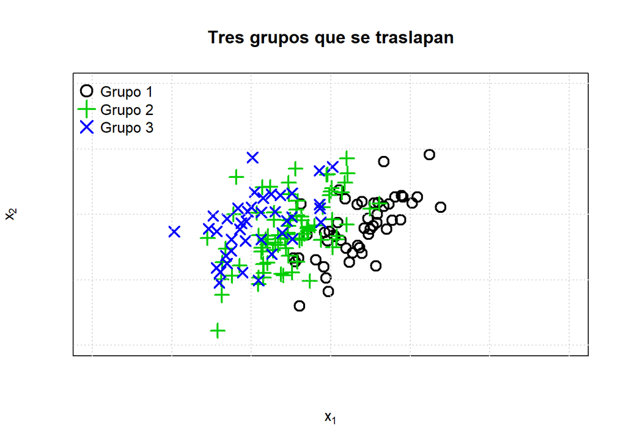

```r
M_cor<-matrix(c(1,0.6,0.6,1),ncol=2)

M_cov<-cor2cov(M_cor,sd=c(1,1))

M_cov_pd<-as.matrix(nearPD(M_cov)$mat)
n1<-50 # Tamaño de la muestra de la clase 1
n2<-80 # Tamaño de la muestra de la clase 2
n3<-40 # Tamaño de la muestra de la clase 2
mu1<-c(0.5,1.5) # Vector de medias de la clase 1
mu2<-c(-1,1.5) # Vector de medias de la clase 2
mu3<-c(-2,1.5) # Vector de medias de la clase 3
set.seed(1)
muestra1<-rmvnorm(n=n1,mean=mu1,sigma=M_cov_pd,method="eigen")
muestra2<-rmvnorm(n=n2,mean=mu2,sigma=M_cov_pd,method="eigen")
muestra3<-rmvnorm(n=n3,mean=mu3,sigma=M_cov_pd,method="eigen")
muestra_nosep<-rbind(muestra1,muestra2,muestra3)
clase<-c(rep(-1,n1),rep(1,n2),rep(2,n3))
muestra_nosep_df<-data.frame(muestra_nosep,clase)


plot(muestra_nosep,
     col=(clase+2),
     pch=(clase+2),
     ylim=c(-2,6),xlim=c(-6,6),
     xaxt="n",yaxt="n",
     xlab=expression(x[1]),
     ylab=expression(x[2]),
     main="Tres grupos que se traslapan",
     las=1,cex=1.5,lwd=2)
grid()
legend("topleft",legend=c("Grupo 1", "Grupo 2","Grupo 3"),
       pch=c(1,3,4),col=c(1,3,4),pt.lwd=2,pt.cex=1.8,bty="n")
```

2. Encontrar los centroides con K-Means fijando el método de inicialización de los centroides. Encuentre los centroides para $n_c$ inicializaciones aleatorias.

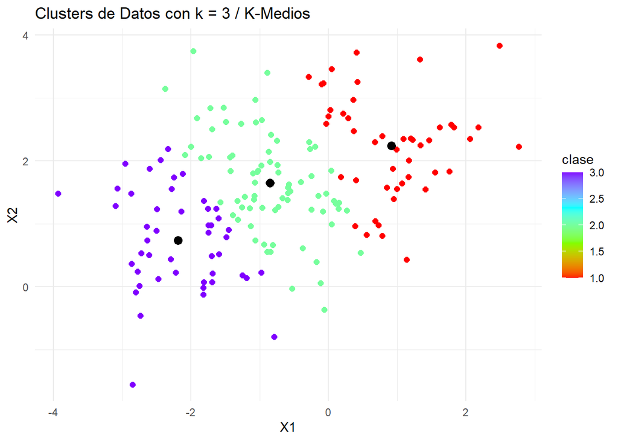

```r
set.seed(1)
kmeans <- kmeans(muestra_nosep_df[,-3], 3)

muestra_nosep_df$clase <- kmeans$cluster

ggplot() + geom_point(aes(x = X1, y = X2, color = clase), data = muestra_nosep_df, size = 2) +
  scale_colour_gradientn(colours=rainbow(4)) +
  geom_point(aes(x = kmeans$centers[, 1], y = kmeans$centers[, 2]), color = 'black', size = 3) +
  ggtitle('Clusters de Datos con k = 3 / K-Medios') +
  xlab('X1') + ylab('X2')+theme_minimal()
```

3. Suponga que el $i$-ésimo individuo es de la forma $X_i = [x_1^i \quad x_2^i]^T$. Cree la variable $x_3$ como $x_3^i=x_1^i+\epsilon_i$ con $\epsilon_i$ iid de media cero y varianza constante. ¿Cuál es la varianza de $x_3$? ¿Cuál es la covarianza entre $x_1$ y $x_3$? ¿Al agregar esta variable K-Means sigue detectando correctamente los centroides? ¿Qué pasa con la estabilidad de los centroides cuando la varianza de $\epsilon$ aumenta?

```r
M_cor<-matrix(c(1,0.6,0.6,1),ncol=2)

M_cov<-(cor2cov(M_cor,sd=c(1,1)))

M_cov_pd<-as.matrix(nearPD(M_cov)$mat)
n1<-50 # Tamaño de la muestra de la clase 1
n2<-80 # Tamaño de la muestra de la clase 2
mu1<-c(0.5,1.5) # Vector de medias de la clase 1
mu2<-c(-1,1.5) # Vector de medias de la clase 2
mu3<-0 # Vector de medias de la clase 3
set.seed(1)
ei=rnorm(n1, mean = 0, sd = 1)
muestra1<-rmvnorm(n=n1,mean=mu1,sigma=M_cov_pd,method="eigen")
muestra2<-rmvnorm(n=n2,mean=mu2,sigma=M_cov_pd,method="eigen")
muestra3<-muestra1 + ei
muestra_nosep1<-rbind(muestra1,muestra2,muestra3)
clase<-c(rep(-1,n1),rep(1,n2),rep(2,nrow(muestra3)))
muestra_nosep_df1<-data.frame(muestra_nosep1,clase)
```

## ¿Cuál es la varianza de $x_3$?

```r
#var(muestra_nosep_df1[muestra_nosep_df1$clase == 2, c(-3)])
var(muestra3)
```

```
##           [,1]      [,2]
## [1,] 1.4677841 0.9360953
## [2,] 0.9360953 1.1417175
```

```r
paste("la varianza x3 es:",var(muestra3)[1,1]+var(muestra3)[2,2],sep = " ")
```

```
## [1] "la varianza x3 es: 2.60950162692468"
```

```r
var(muestra3[,1])
```

```
## [1] 1.467784
```

```r
var(muestra3[,2])
```

```
## [1] 1.141718
```

## ¿Cuál es la covarianza entre $x_1$ y $x_3$?

```r
BD_muesta1_muestra3<-muestra_nosep_df1 %>%
  subset(clase %in% c(-1,2))
BD_muesta1_muestra3<-BD_muesta1_muestra3[,1:2]
#####--- Cálculo del vector de medias y matriz de covarianzas
med=apply(BD_muesta1_muestra3,2,mean)
sc=cov(BD_muesta1_muestra3)           ####### S
s=sc*(n1-1)/n1        ####### Sn=matriz de covarianzas
s
```

```
##           X1        X2
## X1 1.1597309 0.7022751
## X2 0.7022751 0.9600855
```

```r
paste("la covarianza entre x1 y x3 es:",round(s[1,2],3),sep = " ")
```

```
## [1] "la covarianza entre x1 y x3 es: 0.702"
```

```r
paste("la correlación entre x1 y x3 es:",round(cor(BD_muesta1_muestra3[,1],BD_muesta1_muestra3[,2]),3),sep = " ")
```

```
## [1] "la correlación entre x1 y x3 es: 0.666"
```

## ¿Al agregar esta variable K-Means sigue detectando correctamente los centroides?

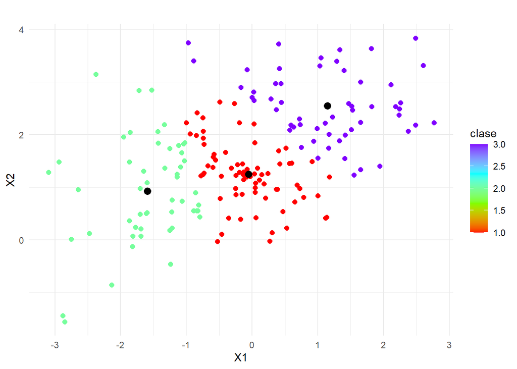

```r
set.seed(1)
kmeans1 <- kmeans(muestra_nosep_df1[,-3], 3)

muestra_nosep_df1$clase <- kmeans1$cluster

ggplot() + geom_point(aes(x = X1, y = X2, color = clase), data = muestra_nosep_df1, size = 2) +
  scale_colour_gradientn(colours=rainbow(4)) +
  geom_point(aes(x = kmeans1$centers[, 1], y = kmeans1$centers[, 2]), color = 'black', size = 3) +
  ggtitle('') +
  xlab('X1') + ylab('X2')+theme_minimal()
```

```r
###Centroides punto 2
cetroid_pun2<- kmeans$centers
cetroid_pun2
```

```
##           X1       X2
## 1  0.9173872 2.240028
## 2 -0.8540011 1.646614
## 3 -2.1873421 0.736740
```

```r
###Centroides cambio en muestra 3
cetroid_pun3<- kmeans1$centers
cetroid_pun3
```

```
##            X1        X2
## 1 -0.05159587 1.2446157
## 2 -1.59414980 0.9266082
## 3  1.14860014 2.5464171
```

```r
paste0("Al agregar la variable x3 se nota un cambio en la posición de los centroides del cluster")
```

```
## [1] "Al agregar la variable x3 se nota un cambio en la posición de los centroides del cluster"
```

## ¿Qué pasa con la estabilidad de los centroides cuando la varianza de $\epsilon$ aumenta?

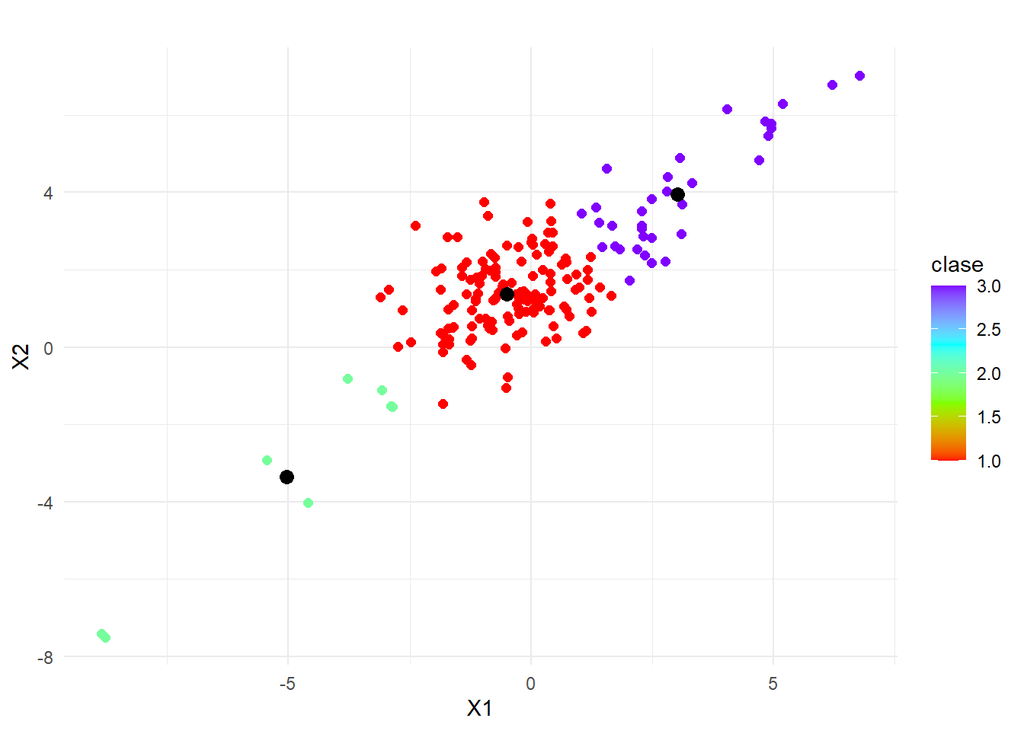

```r
M_cor<-matrix(c(1,0.6,0.6,1),ncol=2)

M_cov<-(cor2cov(M_cor,sd=c(1,1)))

M_cov_pd<-as.matrix(nearPD(M_cov)$mat)
n1<-50 # Tamaño de la muestra de la clase 1
n2<-80 # Tamaño de la muestra de la clase 2
mu1<-c(0.5,1.5) # Vector de medias de la clase 1
mu2<-c(-1,1.5) # Vector de medias de la clase 2
mu3<-0 # Vector de medias de la clase 3
set.seed(1)
ei=rnorm(n1, mean = 0, sd = 4)
muestra1<-rmvnorm(n=n1,mean=mu1,sigma=M_cov_pd,method="eigen")
muestra2<-rmvnorm(n=n2,mean=mu2,sigma=M_cov_pd,method="eigen")
muestra3<-muestra1 + ei
muestra_nosep2<-rbind(muestra1,muestra2,muestra3)
clase<-c(rep(-1,n1),rep(1,n2),rep(2,nrow(muestra3)))
muestra_nosep_df2<-data.frame(muestra_nosep2,clase)

set.seed(1)
kmeans2 <- kmeans(muestra_nosep_df2[,-3], 3)

muestra_nosep_df2$clase <- kmeans2$cluster

ggplot() + geom_point(aes(x = X1, y = X2, color = clase), data = muestra_nosep_df2, size = 2) +
  scale_colour_gradientn(colours=rainbow(4)) +
  geom_point(aes(x = kmeans2$centers[, 1], y = kmeans2$centers[, 2]), color = 'black', size = 3) +
  ggtitle('') +
  xlab('X1') + ylab('X2')+theme_minimal()
```

```r
###Centroides epsilon con desviación standar=1
cetroid_pun3<- kmeans1$centers
cetroid_pun3
```

```
##            X1        X2
## 1 -0.05159587 1.2446157
## 2 -1.59414980 0.9266082
## 3  1.14860014 2.5464171
```

```r
###Centroides epsilon con desviación standar=4
cetroid_pun4<- kmeans2$centers
cetroid_pun4
```

```
##           X1        X2
## 1 -0.4931862  1.366406
## 2 -5.0332454 -3.353521
## 3  3.0190109  3.942491
```

```r
paste0("Al aumentar la varianza del epsilon de la variable x3= x1 + epsilon los centroides cambian")
```

```
## [1] "Al aumentar la varianza del epsilon de la variable x3= x1 + epsilon los centroides cambian"
```

4. Como en el paso anterior, cree las variables $x_4$ y $x_6$ como la suma de $x_2$ y otra variable de media cero y varianza constante y la variable $x_5$ como la suma de $x_3$ y otra variable de media cero y varianza constante. ¿Al agregar estas variables, K-Means sigue detectando correctamente los centroides? ¿Qué pasa cuando la estabilidad de los centroides cuando la varianza de las variables que se suman a las variables originales aumenta?

```r
M_cor<-matrix(c(1,0.6,0.6,1),ncol=2)

M_cov<-(cor2cov(M_cor,sd=c(1,1)))

M_cov_pd<-as.matrix(nearPD(M_cov)$mat)
n1<-50 # Tamaño de la muestra de la clase 1
n2<-60 # Tamaño de la muestra de la clase 2
mu1<-c(0.5,1.5) # Vector de medias de la clase 1
mu2<-c(-1,1.5) # Vector de medias de la clase 2
mu3<-0 # Vector de medias de la clase 3
set.seed(1)
ei=rnorm(n1, mean = 0, sd = 1)
ej=rnorm(n2, mean = 0, sd = 2)
ek=rnorm(n2, mean = 0, sd = 5)
en=rnorm(n1, mean = 0, sd = 4)

muestra1<-rmvnorm(n=n1,mean=mu1,sigma=M_cov_pd,method="eigen")
muestra2<-rmvnorm(n=n2,mean=mu2,sigma=M_cov_pd,method="eigen")
muestra3<-muestra1 + ei
muestra4<-muestra2 + ej
muestra5<-muestra3 + en
muestra6<-muestra2 + ek
muestra_nosep1<-rbind(muestra1,muestra2,muestra3,muestra4,muestra5,muestra6)
clase<-c(rep(-1,n1),rep(1,n2),rep(2,nrow(muestra3)),rep(3,nrow(muestra4)),rep(4,nrow(muestra5)),rep(5,nrow(muestra6)))
muestra_nosep_df1<-data.frame(muestra_nosep1,clase)
```

## ¿Al agregar esta variable K-Means sigue detectando correctamente los centroides?

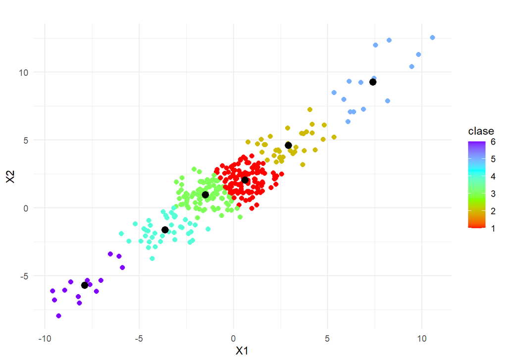

```r
set.seed(1)
kmeans3 <- kmeans(muestra_nosep_df1[,-3], 6)

muestra_nosep_df1$clase <- kmeans3$cluster

ggplot() + geom_point(aes(x = X1, y = X2, color = clase), data = muestra_nosep_df1, size = 2) +
  scale_colour_gradientn(colours=rainbow(4)) +
  geom_point(aes(x = kmeans3$centers[, 1], y = kmeans3$centers[, 2]), color = 'black', size = 3) +
  ggtitle('') +
  xlab('X1') + ylab('X2')+theme_minimal()
```

```r
###Centroides punto 3
cetroid_pun3<- kmeans2$centers
cetroid_pun3
```

```
##           X1        X2
## 1 -0.4931862  1.366406
## 2 -5.0332454 -3.353521
## 3  3.0190109  3.942491
```

```r
###Centroides agregando más variables y aumentando la varianza
cetroid_pun4<- kmeans3$centers
cetroid_pun4
```

```
##           X1         X2
## 1  0.6118035  2.0555689
## 2  2.9161685  4.6229972
## 3 -1.4997137  0.9778477
## 4 -3.6399738 -1.6103290
## 5  7.3938482  9.2747898
## 6 -7.9055742 -5.6834327
```

## ¿Qué pasa cuando la estabilidad de los centroides cuando la varianza de las variables que se suman a las variables originales aumenta?

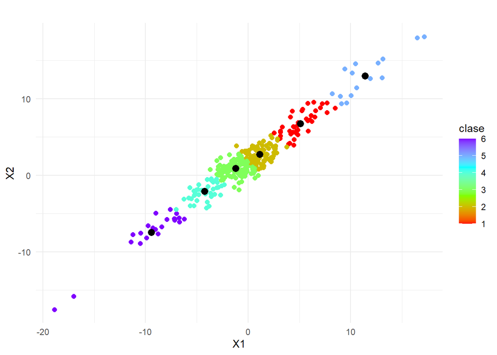

```r
M_cor<-matrix(c(1,0.6,0.6,1),ncol=2)

M_cov<-(cor2cov(M_cor,sd=c(1,1)))

M_cov_pd<-as.matrix(nearPD(M_cov)$mat)
n1<-50 # Tamaño de la muestra de la clase 1
n2<-60 # Tamaño de la muestra de la clase 2
mu1<-c(0.5,1.5) # Vector de medias de la clase 1
mu2<-c(-1,1.5) # Vector de medias de la clase 2
mu3<-0 # Vector de medias de la clase 3
set.seed(1)
ei=rnorm(n1, mean = 0, sd = 3)
ej=rnorm(n2, mean = 0, sd = 4)
ek=rnorm(n2, mean = 0, sd = 6)
en=rnorm(n1, mean = 0, sd = 7)

muestra1<-rmvnorm(n=n1,mean=mu1,sigma=M_cov_pd,method="eigen")
muestra2<-rmvnorm(n=n2,mean=mu2,sigma=M_cov_pd,method="eigen")
muestra3<-muestra1 + ei
muestra4<-muestra2 + ej
muestra5<-muestra3 + en
muestra6<-muestra2 + ek
muestra_nosep1<-rbind(muestra1,muestra2,muestra3,muestra4,muestra5,muestra6)
clase<-c(rep(-1,n1),rep(1,n2),rep(2,nrow(muestra3)),rep(3,nrow(muestra4)),rep(4,nrow(muestra5)),rep(5,nrow(muestra6)))
muestra_nosep_df1<-data.frame(muestra_nosep1,clase)

set.seed(1)
kmeans4 <- kmeans(muestra_nosep_df1[,-3], 6)

muestra_nosep_df1$clase <- kmeans4$cluster

ggplot() + geom_point(aes(x = X1, y = X2, color = clase), data = muestra_nosep_df1, size = 2) +
  scale_colour_gradientn(colours=rainbow(4)) +
  geom_point(aes(x = kmeans4$centers[, 1], y = kmeans4$centers[, 2]), color = 'black', size = 3) +
  ggtitle('') +
  xlab('X1') + ylab('X2')+theme_minimal()
```

```r
###Centroides punto 3
cetroid_anteriores<- kmeans3$centers
cetroid_anteriores
```

```
##           X1         X2
## 1  0.6118035  2.0555689
## 2  2.9161685  4.6229972
## 3 -1.4997137  0.9778477
## 4 -3.6399738 -1.6103290
## 5  7.3938482  9.2747898
## 6 -7.9055742 -5.6834327
```

```r
###Centroides agregando más variables
cetroid_pun4<- kmeans4$centers
cetroid_pun4
```

```
##          X1         X2
## 1  5.084329  6.7727419
## 2  1.122769  2.7539673
## 3 -1.217594  0.9065223
## 4 -4.258527 -2.0935199
## 5 11.387556 12.9974295
## 6 -9.431592 -7.4581402
```

```r
paste0("Al aumentar la varianza del epsilon de la variables nuevas los centroides cambian")
```

```
## [1] "Al aumentar la varianza del epsilon de la variables nuevas los centroides cambian"
```

5. A partir de estos experimentos, ¿qué se podría decir del efecto de la correlación entre variables y la estabilidad de los centroides en K-Medias?
- Al agregar nuevas variables durante la simulación,las variable eran altamente correlacionadas porque eran simuladas a partir de una variable ya conocida y se le sumaba una variable iid con media cero y desviación estandar constante, afectaba el calculo de los centroides de los cluester, ese cambio era mas fuerte a cuando se aumentaba la varianza.